# ML - German_Credit_Risk

## Exploratory Data Analysis

Firstly let’s import the datasets.

```r
df_train <- read_csv(config$dataset$train, show_col_types = FALSE)
df_test <- read_csv(config$dataset$test, show_col_types = FALSE)
```

### Histogram of numerical variables

In order to make a simple data analysis let’s look specifically into numerical variables as they are the only ones present in out dataset.

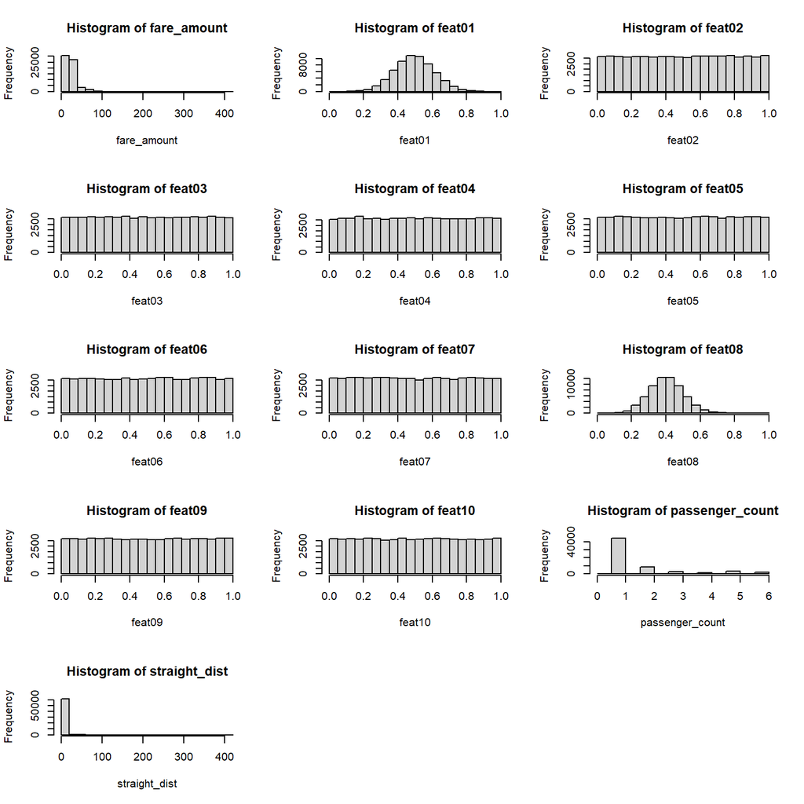

```r
par(mfrow=c(5, 3))
numeric_variables <- names(df_train)[sapply(df_train, is.numeric) & !(names(df_train) %in% c("id", "pickup_date", "pickup_time", 'dropoff_latitude', 'dropoff_longitude', 'pickup_latitude','pickup_longitude'))]
for (var in numeric_variables) {
    hist(df_train[[var]], main=paste("Histogram of", var), xlab=var)
}
```

### Relationship with fare amount.

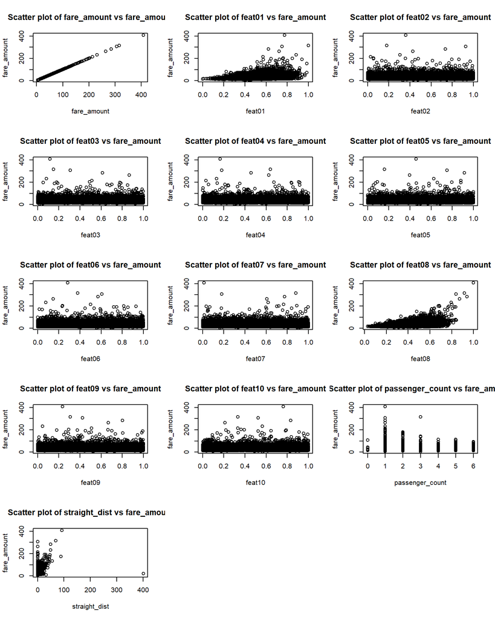

```r
par(mfrow=c(5, 3))
numeric_variables <- names(df_train)[sapply(df_train, is.numeric) & !(names(df_train) %in% c("id", "pickup_date", "pickup_time", 'dropoff_latitude', 'dropoff_longitude', 'pickup_latitude','pickup_longitude'))]
for (var in numeric_variables) {
    plot(df_train[[var]], df_train$fare_amount, main=paste("Scatter plot of", var, "vs fare_amount"), xlab=var, ylab="fare_amount")
}
```

However we have intentionally left earlier analysis of datetime columns. We could theoretically think, based on our own experience, that either hours or amount of calls to the taxi company should be somehow correlated with the price.

### Time dependency of fare variable

Firstly let’s take a look into the distribution of avg. fare price per hour. As we can notice, there is no much of a strict definition, however we can see few hours standing out such as 4,5 and 19,20.

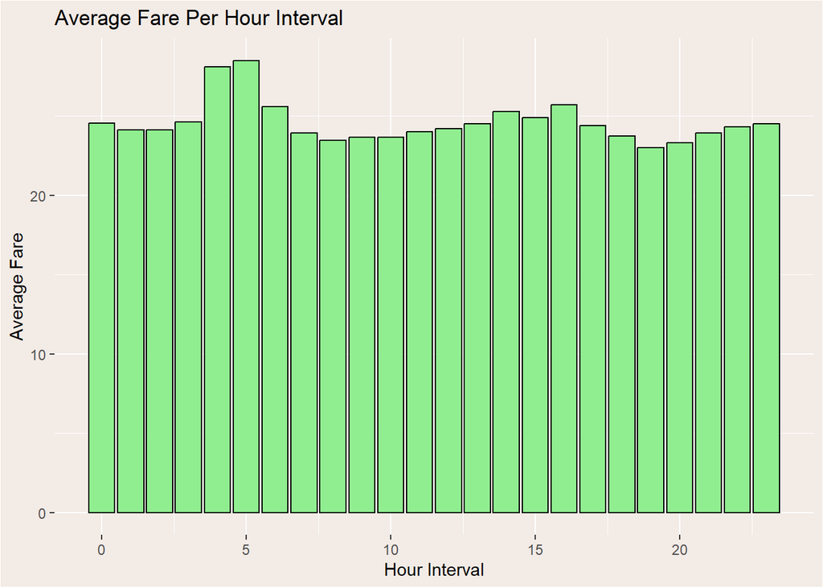

```r
df_train <- df_train %>%
  mutate(hour_numeric = hour(pickup_time))

hourly_interval_stats <- df_train %>%
  group_by(hour_numeric) %>%
  dplyr::summarize(avg_fare = mean(fare_amount, na.rm = TRUE), .groups = "drop") %>%
  arrange(hour_numeric)

ggplot(hourly_interval_stats, aes(x = hour_numeric, y = avg_fare)) +
  geom_bar(stat = "identity", fill = "lightgreen", color = "black") +
  labs(title = "Average Fare Per Hour Interval",
       x = "Hour Interval",
       y = "Average Fare") +
  theme(plot.background = element_rect(fill = "#f2ebe6"),
        panel.background = element_rect(fill = "#f2ebe6"))
```

```r
df_train <- df_train %>%
  mutate(
    time_of_day = as.POSIXct(pickup_time, format = '%T'),
    tenmin_interval = format(ceiling_date(time_of_day, '10 mins'), "%H%M"),
    hour4 = as.integer(hour_numeric == 4),
    hour5 = as.integer(hour_numeric == 5),
    hour19 = as.integer(hour_numeric == 19),
    hour20 = as.integer(hour_numeric == 20)
  )

df_train <- df_train %>%
  group_by(hour_numeric, tenmin_interval) %>%
  mutate(tenmin_count = n()) %>%
  ungroup()

df_train <- df_train %>%
  group_by(tenmin_interval) %>%
  summarize(count = n(), avg_fare = mean(fare_amount)) %>%
  arrange(tenmin_interval) %>%
  left_join(df_train, by = "tenmin_interval")
```

As previously explained we have decided to look into the possible correlation between fare amount and the count of taxi calls throughout 10 minute intervals.

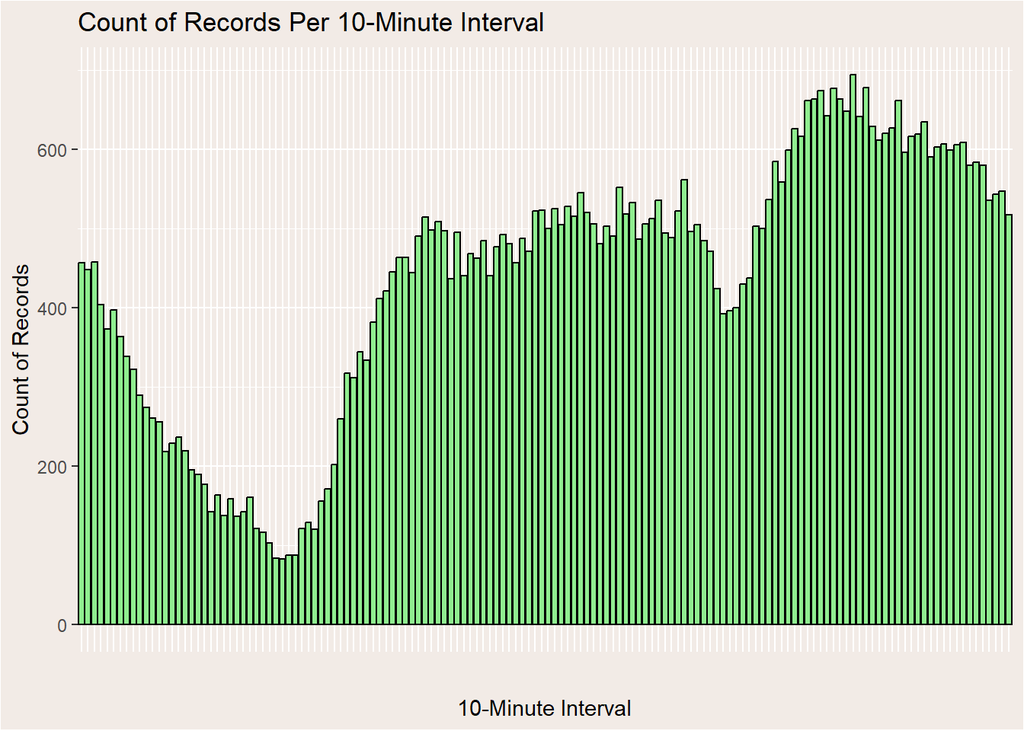

```r
tenmin_interval_stats <- df_train %>%
  group_by(tenmin_interval) %>%
  dplyr::summarize(count = n(), avg_fare = mean(fare_amount, na.rm = TRUE), .groups = "drop") %>%
  arrange(tenmin_interval)

ggplot(tenmin_interval_stats, aes(x = tenmin_interval, y = count)) +
  geom_bar(stat = "identity", fill = "lightgreen", color = "black") +
  labs(title = "Count of Records Per 10-Minute Interval",
       x = "10-Minute Interval",
       y = "Count of Records") +
  theme(axis.text.x = element_blank(), plot.background = element_rect(fill = "#f2ebe6"),
        panel.background = element_rect(fill = "#f2ebe6"),
        axis.ticks.x = element_blank(),
        axis.title.x = element_text(margin = margin(t = 20)))
```

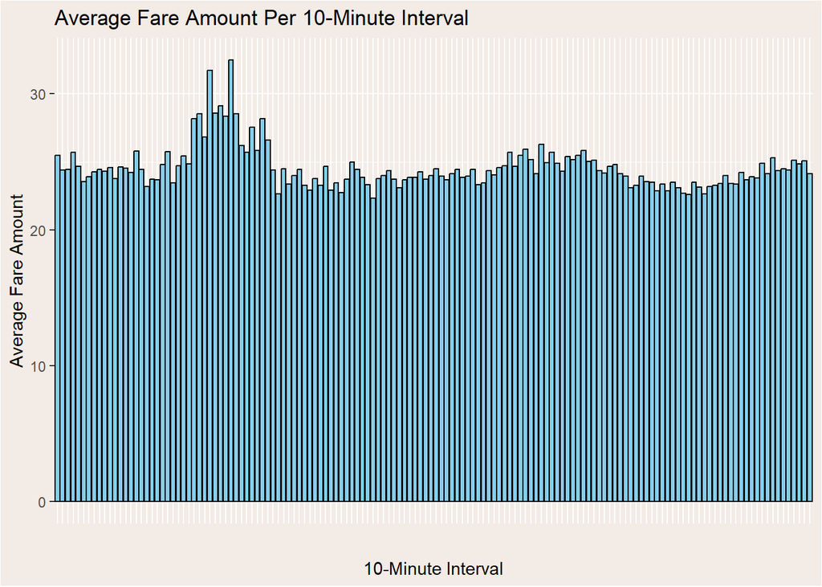

```r
ggplot(tenmin_interval_stats, aes(x = tenmin_interval, y = avg_fare)) +
  geom_bar(stat = "identity", fill = "skyblue", color = "black") +
  labs(title = "Average Fare Amount Per 10-Minute Interval",
       x = "10-Minute Interval",
       y = "Average Fare Amount") +
  theme(axis.text.x = element_blank(), plot.background = element_rect(fill = "#f2ebe6"),
        panel.background = element_rect(fill = "#f2ebe6"),
        axis.ticks.x = element_blank(),
        axis.title.x = element_text(margin = margin(t = 20)))
```

Although there is no strict correlation, we can see a similar behaviour [correlated negatively] among early hours. As for now we have decided to add such variable [count of taxi calls per 10 minute intervals] into the dataset.

```r
df_train <- df_train%>%
  select(-tenmin_interval, -avg_fare, -id, -pickup_time, -pickup_date, -hour_numeric, -time_of_day, -count) %>%
  mutate(zero_indicator = as.integer(zero_indicator))
```

### Correlation plot

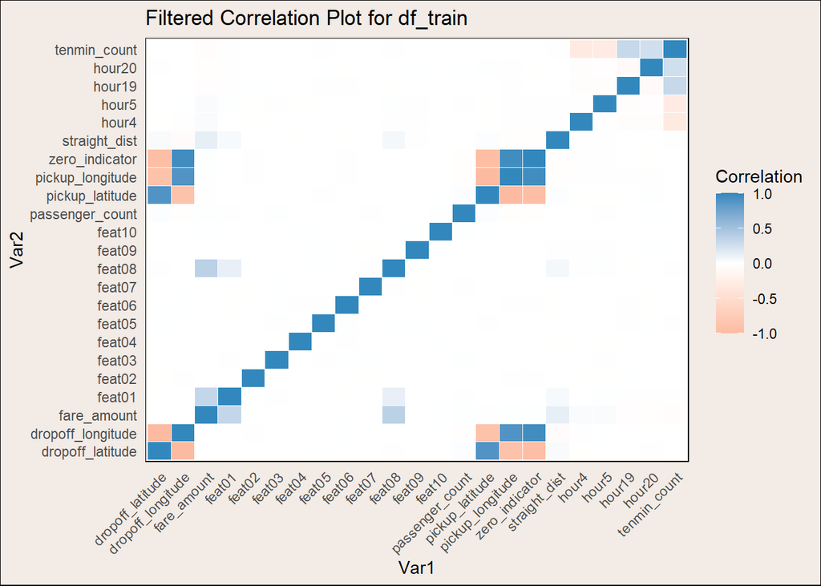

```r
cor_matrix_filtered <- cor(df_train)
cor_matrix_long <- reshape2::melt(cor_matrix_filtered)
ggplot(data = cor_matrix_long, aes(x = Var1, y = Var2, fill = value)) +
  geom_tile(color = "white") +
  scale_fill_gradient2(low = "#fcbba1", high = "#3288bd", mid = "white",
                       midpoint = 0, limit = c(-1, 1), space = "Lab",
                       name = "Correlation") +
  theme_minimal() +
  theme(axis.text.x = element_text(angle = 45, hjust = 1),
        panel.grid.major = element_blank(),
        panel.grid.minor = element_blank(),
        panel.border = element_blank(),
        panel.background = element_rect(fill = "#f2ebe6"),plot.background = element_rect(fill = "#f2ebe6")) +
  ggtitle("Filtered Correlation Plot for df_train")
```

## Hyperparameter tuning and cross_validation

The idea itself for the hyperparameter tunning and the cross-validation was to utilize the whole tidymodels infrastructure in R in order to also compare it’s usability to scikit-learn package for python. As a tool for tuning hypermeters I will use created function that utilizes grid_latin_hypercube as a theoretical space of grids of parameters to search for the most optimal parameter configuration. In order to assess the optimality we will use MAPE metric [Mean absolute percentage error] The tune_two_stages functions works like that: - Import earlier specified parameters of a model that will be tuned - create a workflow model that will pass the model specification into the tuning part - specify number of folds in cross-validation. - tune the first stage [tuning only one of the variables in order to decrease computing complexity] - pass the best performing parameter into further function - tune the second stage [1-3 parameters depending on the model/definition] - autoplot the models which shows how specific parameters impact the validation MAPE value - return and save the top 3 model specification

```r
tune_two_stages <- function(models, model_name) {
  # Extract parameters based on the model_name
  model_params <- models[[model_name]]

  # Stage 1 tuning
  set.seed(123)
  wflw_model_1 <- workflow() %>%
    add_model(model_params$model_1) %>%
    add_recipe(model_params$rec_spec)

  set.seed(123)
  cv_folds <- vfold_cv(df_train, v = 3)
  tune_stage_1 <- tune_grid(
    wflw_model_1,
    resamples = cv_folds,
    grid      = model_params$grid_1,
    metrics   = metric_set(mape),
    control   = control_grid(verbose = TRUE)
  )
  autoplot(tune_stage_1, metric = 'mape')
  best_params_model_1 <- tune_stage_1 %>% collect_metrics() %>% arrange(mean) %>%
    filter(row_number() == 1)
  print(best_params_model_1)
  # Stage 2 tuning
  set.seed(123)
  param_name <- names(model_params$grid_1)[1]
  param_value <- best_params_model_1[[1]]
  print('no1 done')
  # Set up model_2
  model_params$model_2_args[[param_name]] <- param_value
  model_2 <- model_params$model_1 %>%
    set_args(
      !!!model_params$model_2_args
    )
  wflw_model_2 <- wflw_model_1 %>%
    update_model(model_2)

  # Tune stage 2
  set.seed(123)
  tune_stage_2 <- tune_grid(
    wflw_model_2,
    resamples = cv_folds,
    grid      = model_params$grid_2,
    metrics   = metric_set(mape),
    control   = control_grid(verbose = TRUE)
  )

  autoplot(tune_stage_2, metric = 'mape')
  print("1stcheck")
  grid_last <- tune_stage_2
  print("2stcheck")
  all_results <- tune_stage_2 %>% collect_metrics() %>% arrange(mean)
  print("3stcheck")
  result <- all_results %>% filter(row_number() <= 3)
  result[[param_name]] <- best_params_model_1[[1]]
  print("4stcheck")
  return(list(result = result, all_results = all_results, grid = tune_stage_2))
}
```

### Defining model’s grid

Further, let’s define the models grid, which parameters to tune, what type of engine/mode do we utilize and which features do we utilize.

```r
results_list <- list()
models <- list(
  lgbm = list(
    model_name = 'lgbm',
    model_1 = boost_tree(mode = "regression", engine = "lightgbm", learn_rate = tune()),
    model_2_args = list(tree_depth = tune(), loss_reduction = tune(), stop_iter = tune()),
    rec_spec = recipe(fare_amount ~ ., df_train),
    grid_1 = set_seed_grid(grid_latin_hypercube(learn_rate(), size = 8), 123),
    grid_2 = set_seed_grid(grid_latin_hypercube(tree_depth(), loss_reduction(), stop_iter(), size = 8), 123)
  ),
  xgboost = list(
    model_name = 'xgboost',
    model_1 = boost_tree(mode = "regression", engine = "xgboost", learn_rate = tune()),
    model_2_args = list(tree_depth = tune(), loss_reduction = tune(), stop_iter = tune()),
    rec_spec = recipe(fare_amount ~ ., df_train),
    grid_1 = set_seed_grid(grid_latin_hypercube(learn_rate(), size = 8), 123),
    grid_2 = set_seed_grid(grid_latin_hypercube(tree_depth(), loss_reduction(), stop_iter(), size = 8), 123)
  ),
  decision_tree = list(
    model_name = 'decision_tree',
    model_1 = decision_tree(mode = "regression", engine = "rpart", cost_complexity = tune()),
    model_2_args = list(tree_depth = tune(), min_n = tune()),
    rec_spec = recipe(fare_amount ~ ., df_train),
    grid_1 = set_seed_grid(grid_latin_hypercube(cost_complexity(), size = 8), 123),
    grid_2 = set_seed_grid(grid_latin_hypercube(tree_depth(), min_n(), size = 8), 123)
  ),
  random_forest = list(
    model_name = 'random_forest',
    model_1 = rand_forest(mode = "regression", engine = "ranger", mtry = 6, trees = tune()),
    model_2_args = list(min_n = tune()),
    rec_spec = recipe(fare_amount ~ ., df_train),
    grid_1 = set_seed_grid(grid_latin_hypercube(trees(), size = 3), 123),
    grid_2 = set_seed_grid(grid_latin_hypercube(min_n(), size = 3), 123)
  )
)

model_names <- c('lgbm','xgboost','decision_tree','random_forest')
```

### Tuning & cross validation

```r
for (model_name in model_names) {
  result <- tune_two_stages(models, model_name)
  results_list[[model_name]] <- result
  print ("written")
}
```

```
## # A tibble: 1 × 7
##   learn_rate .metric .estimator  mean     n std_err .config
##        <dbl> <chr>   <chr>      <dbl> <int>   <dbl> <chr>
## 1    0.00985 mape    standard    16.1     3  0.0405 Preproc…
## [1] "no1 done"
## [1] "1stcheck"
## [1] "2stcheck"
## [1] "3stcheck"
## [1] "4stcheck"
## [1] "written"
## # A tibble: 1 × 7
##   learn_rate .metric .estimator  mean     n std_err .config
##        <dbl> <chr>   <chr>      <dbl> <int>   <dbl> <chr>
## 1    0.00985 mape    standard    83.8     3  0.0224 Preproc…
## [1] "no1 done"
## [1] "1stcheck"
## [1] "2stcheck"
## [1] "3stcheck"
## [1] "4stcheck"
## [1] "written"
## # A tibble: 1 × 7
##   cost_complexity .metric .estimator  mean     n std_err
##             <dbl> <chr>   <chr>      <dbl> <int>   <dbl>
## 1       0.0000632 mape    standard    10.4     3  0.0961
## # ℹ 1 more variable: .config <chr>
## [1] "no1 done"
## [1] "1stcheck"
## [1] "2stcheck"
## [1] "3stcheck"
## [1] "4stcheck"
## [1] "written"
## # A tibble: 1 × 7
##   trees .metric .estimator  mean     n std_err .config
##   <int> <chr>   <chr>      <dbl> <int>   <dbl> <chr>
## 1  1404 mape    standard    9.88     3  0.0837 Preprocessor…
## [1] "no1 done"
## [1] "1stcheck"
## [1] "2stcheck"
## [1] "3stcheck"
## [1] "4stcheck"
## [1] "written"
```

### Tuning’s results

```r
lgbm_df <- results_list[["lgbm"]]$result %>%
  mutate(Mape = round(mean, 3),
         Mape_Std_Err = round(std_err, 3),
         Model_Type = "Light GBM",
         Model_Spec = paste("learn_rate:", round(learn_rate, 3),
                            "tree_depth:", round(tree_depth, 3),
                            "loss_reduction:", round(loss_reduction, 3),
                            "stop_iter:", round(stop_iter, 3))) %>%
  select(Model_Type, Model_Spec, Mape, Mape_Std_Err)

xgboost_df <- results_list[["xgboost"]]$result %>%
  mutate(Mape = round(mean, 3),
         Mape_Std_Err = round(std_err, 3),
         Model_Type = "XGBoost",
         Model_Spec = paste("learn_rate:", round(learn_rate, 3),
                            "tree_depth:", round(tree_depth, 3),
                            "loss_reduction:", round(loss_reduction, 3),
                            "stop_iter:", round(stop_iter, 3))) %>%
  select(Model_Type, Model_Spec, Mape, Mape_Std_Err)

decision_tree_df <- results_list[["decision_tree"]]$result %>%
  mutate(Mape = round(mean, 3),
         Mape_Std_Err = round(std_err, 3),
         Model_Type = "Decision Tree",
         Model_Spec = paste("tree_depth:", round(tree_depth, 3),
                            "min_n:", round(min_n, 3))) %>%
  select(Model_Type, Model_Spec, Mape, Mape_Std_Err)

random_forest_df <- results_list[["random_forest"]]$result %>%
  mutate(Mape = round(mean, 3),
         Mape_Std_Err = round(std_err, 3),
         Model_Type = "Random Forest",
         Model_Spec = paste("min_n:", round(min_n, 3))) %>%
  select(Model_Type, Model_Spec, Mape, Mape_Std_Err)


combined_table <- bind_rows(lgbm_df, xgboost_df, decision_tree_df, random_forest_df)

datatable(combined_table, options = list(
  searching = FALSE,
  pageLength = 12,
  lengthMenu = c(5, 10, 15, 20),
  scrollX = TRUE
),
width = "100%")
```

|  | Model_Type | Model_Spec | Mape | Mape_Std_Err |
| --- | --- | --- | --- | --- |
| 1 | Light GBM | learn_rate: 0.01 tree_depth: 8 loss_reduction: 0 stop_iter: 15 | 16.103 | 0.042 |
| 2 | Light GBM | learn_rate: 0.01 tree_depth: 14 loss_reduction: 0 stop_iter: 5 | 16.113 | 0.04 |
| 3 | Light GBM | learn_rate: 0.01 tree_depth: 12 loss_reduction: 0 stop_iter: 5 | 16.113 | 0.04 |
| 4 | XGBoost | learn_rate: 0.01 tree_depth: 2 loss_reduction: 0 stop_iter: 18 | 83.545 | 0.015 |
| 5 | XGBoost | learn_rate: 0.01 tree_depth: 4 loss_reduction: 6.891 stop_iter: 9 | 83.693 | 0.02 |
| 6 | XGBoost | learn_rate: 0.01 tree_depth: 5 loss_reduction: 0 stop_iter: 10 | 83.744 | 0.02 |
| 7 | Decision Tree | tree_depth: 13 min_n: 15 | 10.359 | 0.119 |
| 8 | Decision Tree | tree_depth: 12 min_n: 32 | 10.389 | 0.131 |
| 9 | Decision Tree | tree_depth: 10 min_n: 39 | 10.438 | 0.114 |
| 10 | Random Forest | min_n: 4 | 9.877 | 0.081 |

[output cut: 2 more lines]

Based on the upper table we can notice extremely unusal prediction of xgboost models, with extremely high MAPE value in comparison to the other models. Because of that we have decided to use best performing configuration of random forest, decision tree and light gbm model.

## Predicting models on test dataset

Let’s also apply feature engineering do test dataframe as we did with training set.

As we will use best performing models from random forest, lightGBM and decision tree in order to predict the taxi fare for test dataset and compare their MAPE metrics.

### Light GBM

```r
lgbm_model <- boost_tree(
  learn_rate = lgbm_params$learn_rate,
  tree_depth = lgbm_params$tree_depth,
  loss_reduction = lgbm_params$loss_reduction,
  stop_iter = lgbm_params$stop_iter
) %>%
  set_mode("regression") %>%
  set_engine("lightgbm")

# Create a workflow for the LightGBM model
wf_lgbm <- workflow() %>%
  add_model(lgbm_model) %>%
  add_formula(fare_amount ~ .)

# Train the LightGBM model on df_train
wf_lgbm_fit <- wf_lgbm %>% fit(data = df_train)

# Predict on df_test
lgbm_preds <- predict(wf_lgbm_fit, new_data = df_test)

# Calculate MAPE metric for test
mape_lgbm_test <- mean(abs(df_test$fare_amount - lgbm_preds$.pred) / df_test$fare_amount) * 100

# Calculate MAPE metric for train
lgbm_train_preds <- predict(wf_lgbm_fit, new_data = df_train)
mape_lgbm_train <- mean(abs(df_train$fare_amount - lgbm_train_preds$.pred) / df_train$fare_amount) * 100

# Create an iteration dataframe for LightGBM
lgbm_result <- data.frame(
  Mape_test = mape_lgbm_test,
  Mape_train = mape_lgbm_train,
  model_name = "lightgbm"
)
```

### Decision Tree

```r
dt_model <- decision_tree(
  tree_depth = dt_params$tree_depth,
  min_n = dt_params$min_n,
  cost_complexity = dt_params$cp
) %>%
  set_mode("regression") %>%
  set_engine("rpart")

wf_dt <- workflow() %>%
  add_model(dt_model) %>%
  add_formula(fare_amount ~ .)

wf_dt_fit <- wf_dt %>% fit(data = df_train)

dt_preds <- predict(wf_dt_fit, new_data = df_test)

mape_dt_test <- mean(abs(df_test$fare_amount - dt_preds$.pred) / df_test$fare_amount) * 100

dt_train_preds <- predict(wf_dt_fit, new_data = df_train)
mape_dt_train <- mean(abs(df_train$fare_amount - dt_train_preds$.pred) / df_train$fare_amount) * 100

dt_result <- data.frame(
  Mape_test = mape_dt_test,
  Mape_train = mape_dt_train,
  model_name = "decision_tree"
)
```

### Random Forest

```r
rf_model <- rand_forest(
  trees = rf_params$trees,
  min_n = rf_params$min_n,
  mtry = rf_params$mtry
) %>%
  set_mode("regression") %>%
  set_engine("randomForest")

wf_rf <- workflow() %>%
  add_model(rf_model) %>%
  add_formula(fare_amount ~ .)

wf_rf_fit <- wf_rf %>% fit(data = df_train)

rf_preds <- predict(wf_rf_fit, new_data = df_test)

mape_rf_test <- mean(abs(df_test$fare_amount - rf_preds$.pred) / df_test$fare_amount) * 100

rf_train_preds <- predict(wf_rf_fit, new_data = df_train)

mape_rf_train <- mean(abs(df_train$fare_amount - rf_train_preds$.pred) / df_train$fare_amount) * 100

rf_result <- data.frame(
  Mape_test = mape_rf_test,
  Mape_train = mape_rf_train,
  model_name = "random_forest"
)
```

### Compare Results

[output not shown]

### Summary

To sum up, we build several ML models using different approaches. At the end the best result has been obtained by Random Forest [less than 10 MAPE score], however as we could also see Decision Tree has been extremely close in terms of the final prediction, with MAPE score little above 10. Light GBM has been a little bit behind oscilating at around 16 MAPE score. Although random forest having the highest predictive power, the computing complexity of fitting the model works in favor of Decision Tree.

In order to compute from start to finish the random forest, it took around 2 hours of calculation, however decision tree has finished under 30 seconds.

As for usage of tidymodels, it has been rather intuitive throughout the whole project, comparing the feeling and simplicity of usage that we can experience from using scikit-learn in python.